# 2013 Influenza An H7N9 cases in China

This dataste is the the 2013 outbreak of influenza A H7N9 in China, which provided by outbreaks package.

The purpose of this project is to predict disease outcome.

```r
# load Data and Libraries
library(outbreaks)
dataset <- fluH7N9.china.2013
```

## Data exploration

As we can see the summary below, this dataset contains case ID, date of onset, date of hospitalisation, date of outcome, gender, age, province and outcome attributes. In addiction to that, there are a lot of missing data. I will deal with these values latter.

There are 57 cases with unknown outcome. Therefore, this part will be divided into test data.

```r
summary(dataset)
```

```
##     case.ID    date.of.onset        date.of.hospitalisation
##  1      :  1   Min.   :2013-02-19   Min.   :2013-03-03
##  2      :  1   1st Qu.:2013-03-31   1st Qu.:2013-04-01
##  3      :  1   Median :2013-04-08   Median :2013-04-10
##  4      :  1   Mean   :2013-04-07   Mean   :2013-04-13
##  5      :  1   3rd Qu.:2013-04-14   3rd Qu.:2013-04-17
##  6      :  1   Max.   :2013-07-27   Max.   :2013-07-28
##  (Other):130   NA's   :10           NA's   :74
##  date.of.outcome         outcome    gender        age          province
##  Min.   :2013-03-04   Death  :32   f   :39   54     :  6   Zhejiang:46
##  1st Qu.:2013-04-18   Recover:47   m   :95   56     :  6   Shanghai:33
##  Median :2013-04-27   NA's   :57   NA's: 2   38     :  5   Jiangsu :28
##  Mean   :2013-04-28                          69     :  5   Jiangxi : 6
##  3rd Qu.:2013-05-09                          74     :  5   Fujian  : 5
##  Max.   :2013-08-11                          79     :  5   Anhui   : 4
##  NA's   :65                                  (Other):104   (Other) :14
```

```r
str(dataset)
```

```
## 'data.frame':    136 obs. of  8 variables:
##  $ case.ID                : Factor w/ 136 levels "1","2","3","4",..: 1 2 3 4 5 6 7 8 9 10 ...
##  $ date.of.onset          : Date, format: "2013-02-19" "2013-02-27" ...
##  $ date.of.hospitalisation: Date, format: NA "2013-03-03" ...
##  $ date.of.outcome        : Date, format: "2013-03-04" "2013-03-10" ...
##  $ outcome                : Factor w/ 2 levels "Death","Recover": 1 1 1 NA 2 1 1 1 NA 1 ...
##  $ gender                 : Factor w/ 2 levels "f","m": 2 2 1 1 1 1 2 2 2 2 ...
##  $ age                    : Factor w/ 61 levels "?","15","2","21",..: 58 7 11 18 20 9 54 14 39 20 ...
##  $ province               : Factor w/ 13 levels "Anhui","Beijing",..: 11 11 1 8 8 8 8 13 13 11 ...
```

We can see that age have some ? values. We should convert ? values to NA

```r
# convert age ? to NAs
dataset$age[which(dataset$age == "?")] <- NA
```

Before cleaning dataset,let??s look at scatterplots of all pairs of attributes

First, I create datset without NA outcome as test data cannot be used for exploration

```r
dataset_gather <- dataset[!is.na(dataset$outcome),]
```

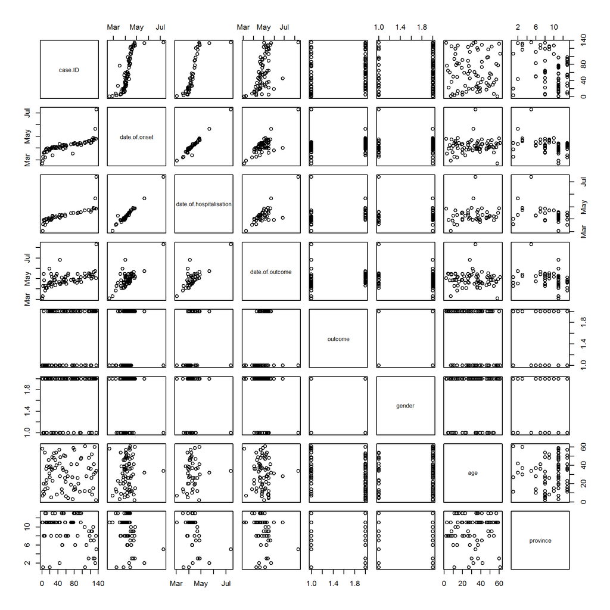

```r
library(GGally)
pairs(dataset_gather)
```

#### Gender

The graph below shows the relationship between gender and outcome

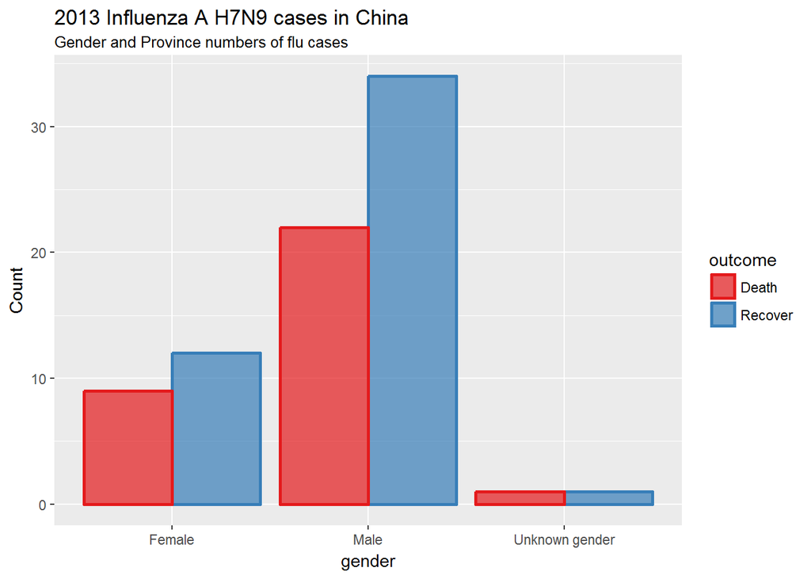

```r
# add a level for unknown gender
levels(dataset_gather$gender) <- c(levels(dataset_gather$gender), "unknown")
dataset_gather$gender[is.na(dataset_gather$gender)] <- "unknown"

# rename gender
library(plyr)
dataset_gather$gender <- mapvalues(dataset_gather$gender, from = c("m", "f", "unknown"),
                                   to = c("Male", "Female", "Unknown gender"))

library(ggplot2)
ggplot(data = dataset_gather, aes(x = gender, fill = outcome, color = outcome))+
    geom_bar(position = "dodge", alpha = 0.7, size = 1) +
    scale_fill_brewer(palette="Set1", na.value = "grey50") +
    scale_color_brewer(palette="Set1", na.value = "grey50") +
    labs(
        y = "Count",
        title = "2013 Influenza A H7N9 cases in China",
        subtitle = "Gender and Province numbers of flu cases"
    )
```

#### Age

Next thing it might be interesting to see the age distribution

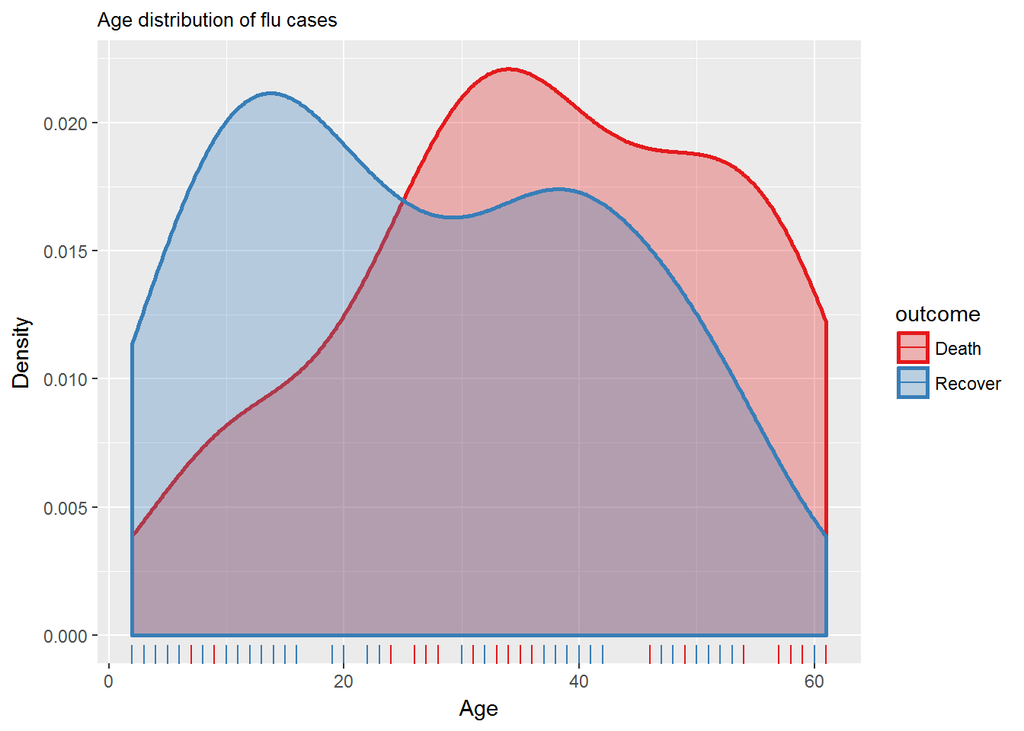

```r
ggplot(data = dataset_gather[!is.na(dataset_gather$age), ], aes(x = as.numeric(age), fill = outcome, color = outcome)) +
  geom_density(alpha = 0.3, size = 1) +
  geom_rug() +
  scale_color_brewer(palette="Set1", na.value = "grey50") +
  scale_fill_brewer(palette="Set1", na.value = "grey50") +
  labs(
    x = "Age",
    y = "Density",
    subtitle = "Age distribution of flu cases"
  )
```

From the density curve above, We can see that people who died tended to be slightly older than those who recovered.

#### Province

Next thing it might be interesting to see if there is any relationship between province and outcome. I only keep Jiangsu, Shanghai and Zhejian and separate provinces and combine other categories to other province as most provinces have only a handful of cases

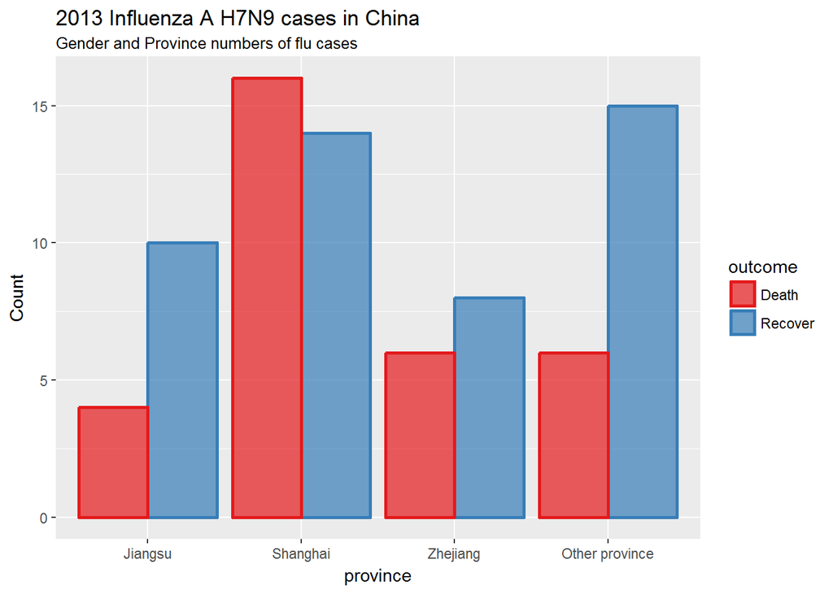

```r
# rename provinces
dataset_gather$province <- mapvalues(dataset_gather$province,
                            from = c("Anhui", "Beijing", "Fujian", "Guangdong", "Hebei", "Henan", "Hunan", "Jiangxi", "Shandong", "Taiwan"),
                            to = rep("Other province", 10))

# rearrange province order so that Other is the last
dataset_gather$province <- factor(dataset_gather$province, levels = c("Jiangsu",  "Shanghai", "Zhejiang", "Other province"))

ggplot(data = dataset_gather, aes(x = province, fill = outcome, color = outcome))+
    geom_bar(position = "dodge", alpha = 0.7, size = 1) +
    scale_fill_brewer(palette="Set1", na.value = "grey50") +
    scale_color_brewer(palette="Set1", na.value = "grey50") +
    labs(
        y = "Count",
        title = "2013 Influenza A H7N9 cases in China",
        subtitle = "Gender and Province numbers of flu cases"
    )
```

Most unknown outcomes were recorded in Zhejiang and Shanghai has the hightest death cases.

#### Date

To see how many days passed between onset, hospitalisation and outcome for each case, let’s plot the dates form each cases.

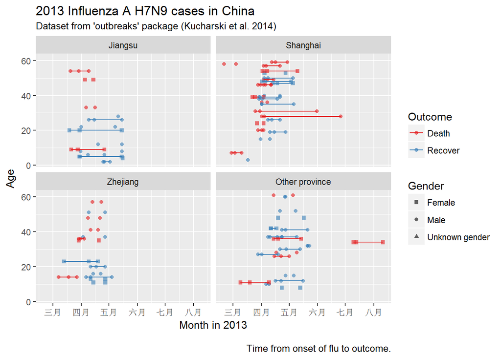

```r
# gather for plotting with ggplot2
library(tidyr)
dataset_gather_2 <- dataset_gather %>%
    gather(Group, Date, date.of.onset:date.of.outcome)

# rearrange group order
dataset_gather_2$Group <- factor(dataset_gather_2$Group, levels = c("date.of.onset", "date.of.hospitalisation", "date.of.outcome"))

# rename groups
dataset_gather_2$Group <- mapvalues(dataset_gather_2$Group, from = c("date.of.onset", "date.of.hospitalisation", "date.of.outcome"),
            to = c("Date of onset", "Date of hospitalisation", "Date of outcome"))

ggplot(data = dataset_gather_2, aes(x = Date, y = as.numeric(age), color = outcome)) +
    geom_point(aes(shape = gender), size = 1.5, alpha = 0.6) +
    geom_path(aes(group = case.ID)) +
    facet_wrap( ~ province, ncol = 2) +
    scale_shape_manual(values = c(15, 16, 17)) +
    scale_color_brewer(palette="Set1", na.value = "grey50") +
    scale_fill_brewer(palette="Set1") +
    labs(
        color = "Outcome",
        shape = "Gender",
        x = "Month in 2013",
        y = "Age",
        title = "2013 Influenza A H7N9 cases in China",
        subtitle = "Dataset from 'outbreaks' package (Kucharski et al. 2014)",
        caption = "\nTime from onset of flu to outcome."
    )
```

It is hard to draw a general conclusion as there are many missing values in the dates. Therefore, I will dig into the days between onset and outcome and between onset and hospitalisation.

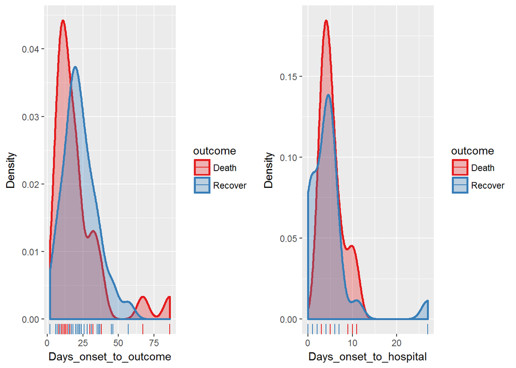

```r
#calculate days_onset_to_outcome
dataset_gather$days_onset_to_outcome <- as.numeric(as.character(gsub(" days", "",
                               as.Date(as.character(dataset_gather$date.of.outcome), format = "%Y-%m-%d") -
                               as.Date(as.character(dataset_gather$date.of.onset), format = "%Y-%m-%d"))))

#calculate days_onset_to_hospital
dataset_gather$days_onset_to_hospital <- as.numeric(as.character(gsub(" days", "",
                        as.Date(as.character(dataset_gather$date.of.hospitalisation), format = "%Y-%m-%d") -
                        as.Date(as.character(dataset_gather$date.of.onset), format = "%Y-%m-%d"))))

p1 <- ggplot(data = dataset_gather[!is.na(dataset_gather$days_onset_to_outcome), ], aes(x = days_onset_to_outcome, fill = outcome, color = outcome)) +
    geom_density(alpha = 0.3, size = 1) +
    geom_rug() +
    scale_color_brewer(palette="Set1", na.value = "grey50") +
    scale_fill_brewer(palette="Set1", na.value = "grey50") +
    labs(
        x = "Days_onset_to_outcome",
        y = "Density"
    )

p2 <- ggplot(data = dataset_gather[!is.na(dataset_gather$days_onset_to_hospital), ], aes(x = days_onset_to_hospital, fill = outcome, color = outcome)) +
    geom_density(alpha = 0.3, size = 1) +
    geom_rug() +
    scale_color_brewer(palette="Set1", na.value = "grey50") +
    scale_fill_brewer(palette="Set1", na.value = "grey50") +
    labs(
        x = "Days_onset_to_hospital",
        y = "Density"
    )

library(gridExtra)
library(grid)

grid.arrange(p1, p2, ncol = 2)
```

As we can see from the first density curve, people who have this disease will die in a short period of time. If the patients cannot recover within the specified period of time, they are more likely to die.

The second density curve shows that shortening the days between onset and hospitalisation can decrease the death rate

Next, I want to plot whether early onset patients have different outcome

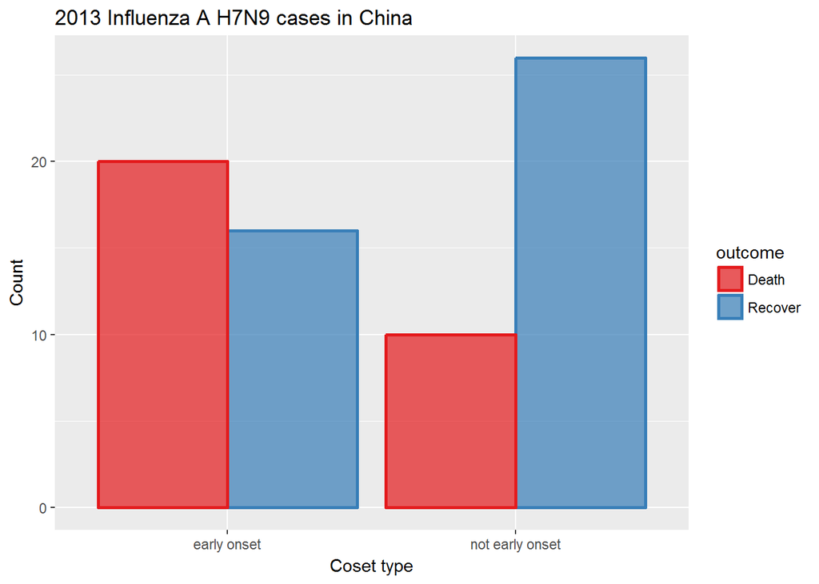

```r
dataset_gather$early_onset = as.factor(ifelse(dataset_gather$date.of.onset < summary(dataset_gather$date.of.onset)[[3]], 'early onset', 'not early onset'))

ggplot(data = dataset_gather[!is.na(dataset_gather$early_onset), ], aes(x = early_onset, fill = outcome, color = outcome))+
    geom_bar(position = "dodge", alpha = 0.7, size = 1) +
    scale_fill_brewer(palette="Set1", na.value = "grey50") +
    scale_color_brewer(palette="Set1", na.value = "grey50") +
    labs(
        x = "Coset type",
        y = "Count",
        title = "2013 Influenza A H7N9 cases in China"
    )
```

As expected, early onset patients have higher number of death.

## Data wrangling

```r
#convert gender into numeric values with 1 for female and 0 for male
dataset$gender_f <- as.factor(ifelse(dataset$gender == "f", 1, 0))

#convert provinces to binary classifiers (yes == 1, no == 0) for Shanghai, Zhejiang, Jiangsu and other provinces
dataset$province_Jiangsu = as.factor(ifelse(dataset$province == "Jiangsu", 1, 0))
dataset$province_Shanghai = as.factor(ifelse(dataset$province == "Shanghai", 1, 0))
dataset$province_Zhejiang = as.factor(ifelse(dataset$province == "Zhejiang", 1, 0))
dataset$province_other = as.factor(ifelse(dataset$province == "Zhejiang" | dataset$province == "Jiangsu" | dataset$province == "Shanghai", 0, 1))

#calculate days_onset_to_outcome
dataset$days_onset_to_outcome <- as.numeric(as.character(gsub(" days", "",
                               as.Date(as.character(dataset$date.of.outcome), format = "%Y-%m-%d") -
                               as.Date(as.character(dataset$date.of.onset), format = "%Y-%m-%d"))))

#calculate days_onset_to_hospital
dataset$days_onset_to_hospital <- as.numeric(as.character(gsub(" days", "",
                        as.Date(as.character(dataset$date.of.hospitalisation), format = "%Y-%m-%d") -
                        as.Date(as.character(dataset$date.of.onset), format = "%Y-%m-%d"))))


#the same binary classification is given for whether a case was hospitalised, and whether they had an early onset or early outcome
dataset$hospital = as.factor(ifelse(is.na(dataset$date.of.hospitalisation), 0, 1))

dataset$early_onset = as.factor(ifelse(dataset$date.of.onset < summary(dataset$date.of.onset)[[3]], 1, 0))

dataset$early_outcome = as.factor(ifelse(dataset$date.of.outcome < summary(dataset$date.of.outcome)[[3]], 1, 0))

#change age data type
dataset$age = as.numeric(dataset$age)

dataset <- subset(dataset, select = -c(2:4, 6, 8))
```

### Imputing missing data

Now we need to check for missing values and look the number and proportion of missing values for each variable using the sapply() function.

```r
#check all missing values
sapply(dataset,function(x) sum(is.na(x)))
```

```
##                case.ID                outcome                    age
##                      0                     57                      2
##               gender_f       province_Jiangsu      province_Shanghai
##                      2                      0                      0
##      province_Zhejiang         province_other  days_onset_to_outcome
##                      0                      0                     67
## days_onset_to_hospital               hospital            early_onset
##                     74                      0                     10
##          early_outcome
##                     65
```

```r
pMiss <- function(x){sum(is.na(x))/length(x)*100}
apply(dataset,2,pMiss)
```

```
##                case.ID                outcome                    age
##               0.000000              41.911765               1.470588
##               gender_f       province_Jiangsu      province_Shanghai
##               1.470588               0.000000               0.000000
##      province_Zhejiang         province_other  days_onset_to_outcome
##               0.000000               0.000000              49.264706
## days_onset_to_hospital               hospital            early_onset
##              54.411765               0.000000               7.352941
##          early_outcome
##              47.794118
```

We can see that date.of.hospitalisation and date.of.outcome are missing more than 45 percentage, therefore we consider to Use mice package for looking at missing data pattern.

```r
library(mice)
md.pattern(dataset[, -c(2)])
```

```
##    case.ID province_Jiangsu province_Shanghai province_Zhejiang
## 42       1                1                 1                 1
## 27       1                1                 1                 1
## 20       1                1                 1                 1
##  2       1                1                 1                 1
## 37       1                1                 1                 1
##  6       1                1                 1                 1
##  2       1                1                 1                 1
##          0                0                 0                 0
##    province_other hospital age gender_f early_onset early_outcome
## 42              1        1   1        1           1             1
## 27              1        1   1        1           1             1
## 20              1        1   1        1           1             0
##  2              1        1   1        1           0             1
## 37              1        1   1        1           1             0
##  6              1        1   1        1           0             0
##  2              1        1   0        0           0             0
##                 0        0   2        2          10            65
##    days_onset_to_outcome days_onset_to_hospital
## 42                     1                      1   0
## 27                     1                      0   1
## 20                     0                      1   2
##  2                     0                      0   3
## 37                     0                      0   3
##  6                     0                      0   4
##  2                     0                      0   6
##                       67                     74 220
```

The output tells us that 42 samples are complete, 27 samples miss only the date.of.hospitalisation attribute, 20 samples miss only the date.of.outcome attribute and so on.

The mice() function takes care of the imputing process

```r
dataset_impute <- mice(dataset[, -c(2)], print = FALSE, seed=500)
summary(dataset_impute)
```

```
## Multiply imputed data set
## Call:
## mice(data = dataset[, -c(2)], printFlag = FALSE, seed = 500)
## Number of multiple imputations:  5
## Missing cells per column:
##                case.ID                    age               gender_f
##                      0                      2                      2
##       province_Jiangsu      province_Shanghai      province_Zhejiang
##                      0                      0                      0
##         province_other  days_onset_to_outcome days_onset_to_hospital
##                      0                     67                     74
##               hospital            early_onset          early_outcome
##                      0                     10                     65
## Imputation methods:
##                case.ID                    age               gender_f
##                     ""                  "pmm"               "logreg"
##       province_Jiangsu      province_Shanghai      province_Zhejiang
##                     ""                     ""                     ""
##         province_other  days_onset_to_outcome days_onset_to_hospital
##                     ""                  "pmm"                  "pmm"
##               hospital            early_onset          early_outcome
##                     ""               "logreg"               "logreg"
## VisitSequence:
##                    age               gender_f  days_onset_to_outcome
##                      2                      3                      8
## days_onset_to_hospital            early_onset          early_outcome
##                      9                     11                     12
## PredictorMatrix:
##                        case.ID age gender_f province_Jiangsu
## case.ID                      0   0        0                0
## age                          1   0        1                1
## gender_f                     1   1        0                1
## province_Jiangsu             0   0        0                0
## province_Shanghai            0   0        0                0
## province_Zhejiang            0   0        0                0
## province_other               0   0        0                0
## days_onset_to_outcome        1   1        1                1
## days_onset_to_hospital       1   1        1                1
## hospital                     0   0        0                0
## early_onset                  1   1        1                1
```

[output cut: 26 more lines]

```
## early_outcome                              1                      1
##                        hospital early_onset early_outcome
## case.ID                       0           0             0
## age                           1           1             1
## gender_f                      1           1             1
## province_Jiangsu              0           0             0
## province_Shanghai             0           0             0
## province_Zhejiang             0           0             0
## province_other                0           0             0
## days_onset_to_outcome         1           1             1
## days_onset_to_hospital        1           1             1
## hospital                      0           0             0
## early_onset                   1           0             1
## early_outcome                 1           1             0
## Random generator seed value:  500
```

Next, we can the complete() function to fill in missing values and merge the completed dataset with outcome column

```r
dataset_complete <- complete(dataset_impute,1)
dataset_complete <- merge(dataset[, c(1,2), drop = FALSE], dataset_complete, by = "case.ID", all = TRUE)

#remove case.ID attribute
dataset_complete <- dataset_complete[, -1]

summary(dataset_complete$days_onset_to_outcome)
```

```
##    Min. 1st Qu.  Median    Mean 3rd Qu.    Max.
##    2.00   12.00   15.50   17.94   20.00   86.00
```